# State Level Mobility Report

## Overview

This short report summarizes trends in student cohorts and mobility, focusing on participation in the state *mathematics* assessment during the *2023-2024* academic year. While *2023-2024* serves as the primary lens, the dataset spans from *2019-2020 to 2023-2024*, allowing for the identification of longer-term patterns across academic years. The analysis is based on the presence or absence of individual *student assessment record*s in each year, which serves as a proxy for enrollment or participation. However, it may not fully capture students represented in the system in other ways—such as through partial-year enrollment or administrative records without assessment data—and therefore may underrepresent true enrollment. Future analyses may benefit from incorporating dedicated enrollment records for more complete insights. This report draws on *67,406* unique students from the `sgpData_Long` dataset.

## Student Population

This section provides an overview of the available student data, including enrollment counts by grade and year. These figures establish the foundation for understanding cohort patterns, mobility trends, and the scope of analysis in subsequent sections.

The table below provides the number of students by year and grade levels based on the available data. In 2023-2024, total enrollment was 37,965, an increase of 0.9% from the previous year. 2023-2024 had the highest enrollment on record. On average, enrollment by grade changed about 4% compared to the same grade’s feeder level in the prior year. The largest change was in grade 9 with a 10.3% increase. Grades with consistently higher enrollment across years included 9 . Changes in enrollment were fairly consistent across grades. No unusual enrollment patterns were detected in any grade. Enrollment varied by about 939 students across years.

Student enrollment summary by grade and year. Diagonals may be interpreted as cohorts.

| Grade Level | 2019-2020 | 2020-2021 | 2021-2022 | 2022-2023 | 2023-2024 |
| --- | --- | --- | --- | --- | --- |
| 3 | 4323 | 4502 | 4477 | 4695 | 4863 |
| 4 | 4405 | 4444 | 4574 | 4575 | 4792 |
| 5 | 4282 | 4498 | 4532 | 4646 | 4618 |
| 6 | 4462 | 4370 | 4518 | 4598 | 4756 |
| 7 | 4579 | 4673 | 4541 | 4538 | 4634 |
| 8 | 4427 | 4703 | 4742 | 4536 | 4598 |
| 9 | 4894 | 4808 | 5104 | 5231 | 5001 |
| 10 | 4248 | 4460 | 4553 | 4821 | 4703 |
| Total | 35620 | 36458 | 37041 | 37640 | 37965 |

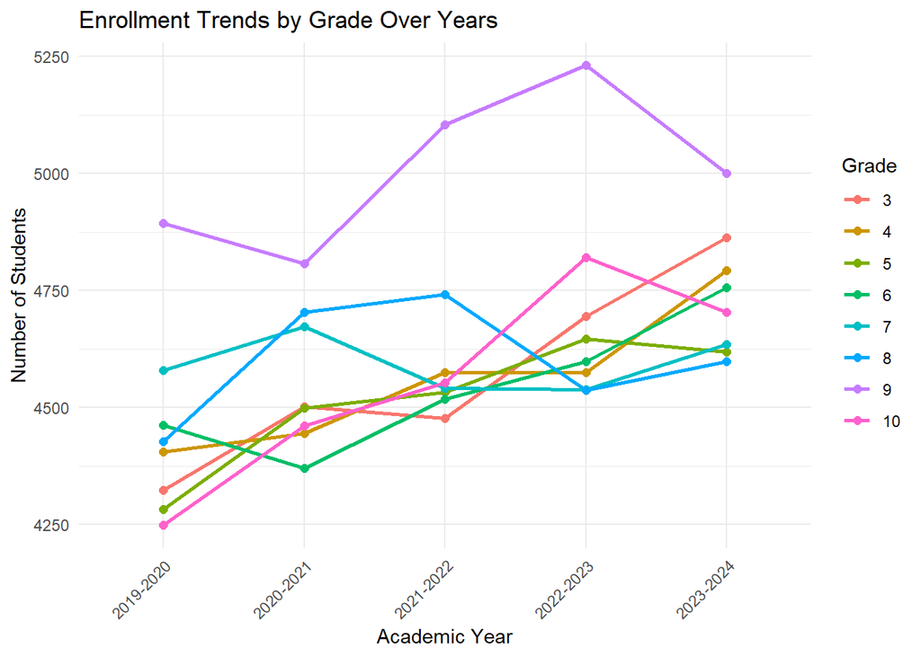

## Definitions

A student has a mobility status of:

- **Leave**: Enrolled last year but not enrolled this year.
- **Stay**: Enrolled in both last year and this year.
- **Join**: Enrolled this year but not last year.
- **Repeat**: In the same grade two years in a row.
- **Advance**: Skipped one or more grades between years.

In cohortED, a trajectory is defined as:

- **Trajectory**: A student’s observed sequence of grade-level placements across academic years, starting from their first appearance in the dataset. In `cohortED`, trajectories assume linear grade progression (one grade per year). Students who skip or repeat a grade are treated as exiting the cohort at the point of deviation, unless handled by specialized functions.

Enrollment and grade transitions are classified as follows:

- **Enrolled**: Student appears in consecutive academic years or for the first time.
- **Return**: Student reappears in the dataset after missing one or more years.
- **Stay**: Advanced one grade level over one year (typical progression). Synonymous with the definition of “Stay” for Cohorts.
- **Repeat**: Remained in the same grade across two consecutive years.
- **Skip**: Advanced more than one grade level in a single year.
- **Drop_Back**: Moved backward in grade level or regressed after a gap.

## General Trends in Student Mobility and Cohorts

To better understand student mobility, consider the heatmap below, which tracks how long students remain in their expected educational trajectory. Each row represents a different grade level, and each column shows the number or percentage of students from the original cohort who are still enrolled in that grade in subsequent years. One cohort includes 4,323 students who were first observed in Grade 3 during the 2019–2020 school year. One year later, 89.8% of those students progressed to Grade 4. This number gradually declines each year, with only 74.4% of the original group reaching Grade 7 by 2023–2024.

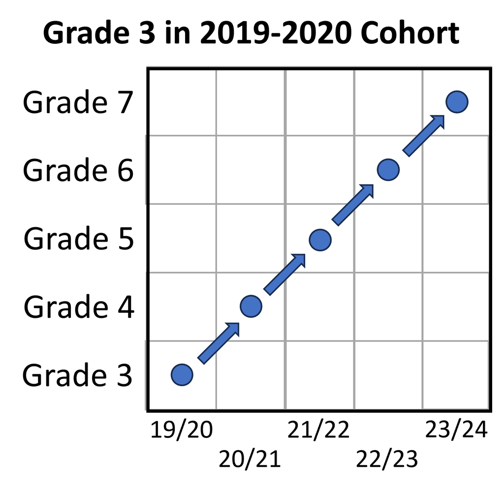

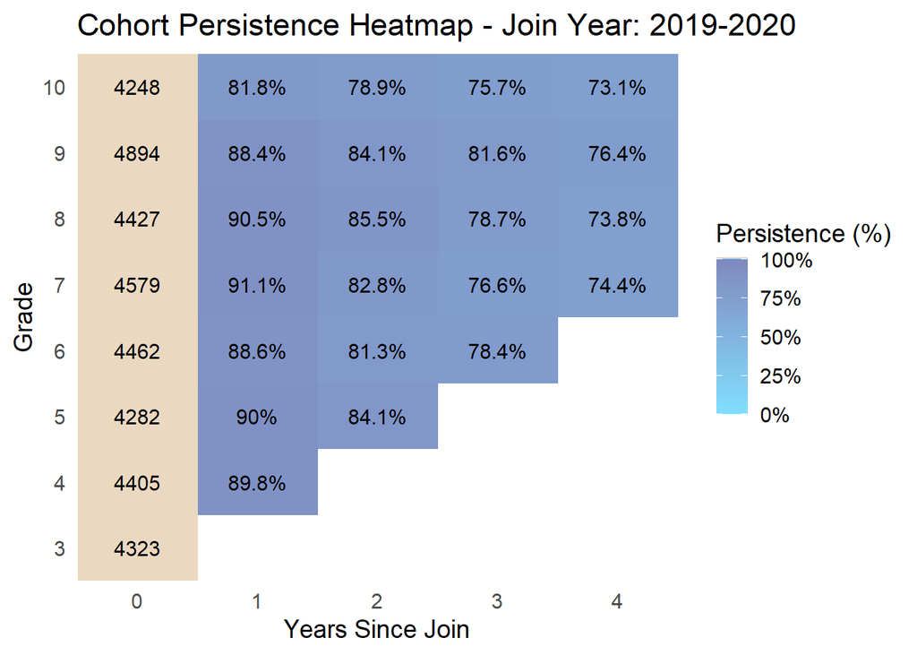

Based on the table below, the overall trend for students for the 2023-2024 academic year seem to be that there is little difference in the mobility of students based on the grade level. Approximately 80% of students from each grade in 2023-2024 continued from the previous grade during the previous academic year. Students appear to be joining at a slightly higher rate than leaving.

Mobility Distribution by Grade Transition for 2023-2024

|  | From Grade 3 to Grade 4 | From Grade 4 to Grade 5 | From Grade 5 to Grade 6 |
| --- | --- | --- | --- |
| Leave | 8.5% | 8.0% | 9.3% |
| Stay | 81.0% | 83.2% | 79.4% |
| Join | 10.4% | 8.8% | 11.4% |

Also of interest is how these cohorts of students compare to one another and to previous cohorts of students. This is evident in the plot shown below. Until more recently, it was common for the percent proficient to increase from Grade 3 to Grade 4. However, this appears to have reversed post-COVID. Additionally, it appears that the percent proficient decreases between Grade 4 and Grade 5, with a much sharper decline in the recent years. It also appears that while most cohorts start with approximately the same proficiency rate in Grade 3, the gap tends to widen as the grade levels increase.

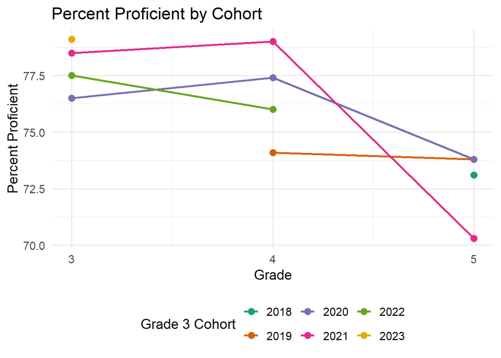

## Deep Dive into Student Mobility and Cohorts

Mobility from Grade 4 ( 2022-2023 ) to Grade 5 ( 2023-2024 ) was analyzed by gender and ethnicity. The alluvial diagram highlights how those patterns intersect with key demographic groups. Differences by gender were most pronounced among Gender: Female students. Larger differences emerged by ethnicity, particularly for Hispanic students. Across gender groups, the largest observed gap in mobility rates was 76.2 percentage points. Gender: Female students were most likely to be categorized as ‘Stay’ (83.4%), and least likely as ‘Leave’ (7.2%), indicating notable variation. Among ethnic groups, the largest gap was 79.5 percentage points. Hispanic students had the highest share in the ‘Stay’ category (86.3%), and the lowest in ‘Leave’ (6.8%), reflecting meaningful variation across groups. When examining intersections of gender and ethnicity, the highest observed mobility rate was among Gender: Male African American students who were classified as ‘Leave’ (24.4%). This suggests that certain demographic subgroups may experience elevated levels of mobility.

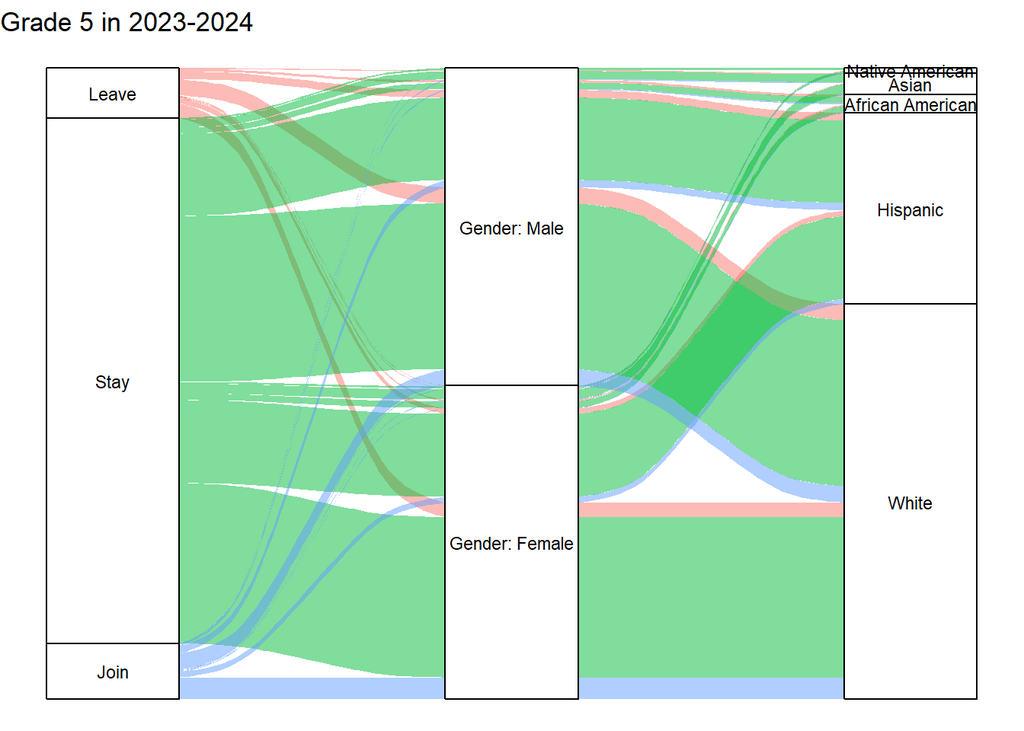

When comparing mobility patterns, non-White students were, on average: Leave 13.4%, Stay 75.8%, Join 10.8% . In contrast, White students were: Leave 7.8%, Stay 82.6%, Join 9.6% . These differences may reflect broader trends in how student mobility intersects with race and ethnicity. The difference in ‘Stay’ rates alone was 6.8% which may warrant further exploration of systemic or contextual factors. Mobility rates varied across ethnic groups, with Hispanic students showing the greatest differences across categories. This suggests that ethnicity may be associated with meaningful variation in student movement.

Demographics of Students from Grade 4 in 2022-2023 to Grade 5 in 2023-2024

|  | Native American | Asian | African American | Hispanic | White |
| --- | --- | --- | --- | --- | --- |
| Leave | 17.8% | 7.7% | 21.4% | 6.8% | 7.8% |
| Stay | 64.4% | 83.4% | 69.0% | 86.3% | 82.6% |
| Join | 17.8% | 8.9% | 9.7% | 6.8% | 9.6% |

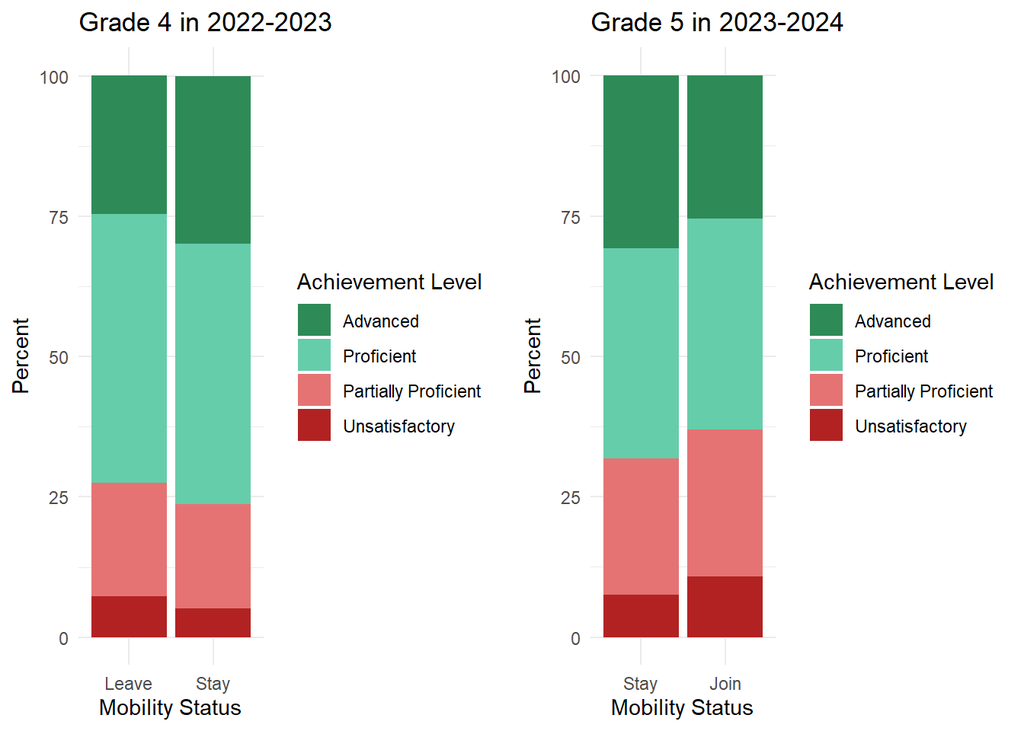

## Data Notes

Note: This report is based on a demonstration dataset derived from the `sgpData_Long` dataset in the `SGPData` R package. The data has been subset to include only mathematics content area records. While it does not reflect actual student attendance, it preserves realistic patterns of student entry and exit. This allows the analysis to focus on student mobility, including those who join or leave the dataset over time.

## Appendices

Summary of student cohorts by grade and year.

| Cohort | 2019-2020 | 2020-2021 | 2021-2022 | 2022-2023 | 2023-2024 | 2024-2025 | 2025-2026 | 2026-2027 |
| --- | --- | --- | --- | --- | --- | --- | --- | --- |
| Grade 3 in 2019 | 4323 | 3881 | 3634 | 3391 | 3215 |  |  |  |
| Grade 4 in 2019 |  | 4405 | 3964 | 3581 | 3374 | 3252 |  |  |
| Grade 5 in 2019 |  |  | 4282 | 3794 | 3547 | 3372 | 3273 |  |
| Grade 6 in 2019 |  |  |  | 4462 | 4064 | 3816 | 3639 | 3262 |
| Grade 7 in 2019 |  |  |  |  | 4579 | 4145 | 3850 | 3465 |
| Grade 8 in 2019 |  |  |  |  |  | 4427 | 3914 | 3493 |
| Grade 9 in 2019 |  |  |  |  |  |  | 4894 | 4003 |
| Grade 10 in 2019 |  |  |  |  |  |  |  | 4248 |
| Grade 3 in 2020 | 4487 | 4042 | 3808 | 3553 |  |  |  |  |
| Grade 4 in 2020 |  | 552 | 449 | 390 | 350 |  |  |  |
| Grade 5 in 2020 |  |  | 529 | 422 | 359 | 333 |  |  |
| Grade 6 in 2020 |  |  |  | 553 | 440 | 381 | 360 |  |
| Grade 7 in 2020 |  |  |  |  | 588 | 470 | 396 | 332 |
| Grade 8 in 2020 |  |  |  |  |  | 533 | 409 | 316 |
| Grade 9 in 2020 |  |  |  |  |  |  | 751 | 565 |
| Grade 10 in 2020 |  |  |  |  |  |  |  | 400 |
| Grade 3 in 2021 | 4455 | 4056 | 3792 |  |  |  |  |  |
| Grade 4 in 2021 |  | 508 | 408 | 345 |  |  |  |  |
| Grade 5 in 2021 |  |  | 425 | 324 | 276 |  |  |  |
| Grade 6 in 2021 |  |  |  | 478 | 382 | 332 |  |  |
| Grade 7 in 2021 |  |  |  |  | 487 | 374 | 329 |  |
| Grade 8 in 2021 |  |  |  |  |  | 407 | 302 | 252 |
| Grade 9 in 2021 |  |  |  |  |  |  | 673 | 508 |
| Grade 10 in 2021 |  |  |  |  |  |  |  | 361 |
| Grade 3 in 2022 | 4682 | 4237 |  |  |  |  |  |  |
| Grade 4 in 2022 |  | 491 | 394 |  |  |  |  |  |
| Grade 5 in 2022 |  |  | 398 | 309 |  |  |  |  |
| Grade 6 in 2022 |  |  |  | 454 | 358 |  |  |  |
| Grade 7 in 2022 |  |  |  |  | 373 | 286 |  |  |
| Grade 8 in 2022 |  |  |  |  |  | 347 | 262 |  |
| Grade 9 in 2022 |  |  |  |  |  |  | 617 | 430 |
| Grade 10 in 2022 |  |  |  |  |  |  |  | 355 |
| Grade 3 in 2023 | 4853 |  |  |  |  |  |  |  |
| Grade 4 in 2023 |  | 536 |  |  |  |  |  |  |
| Grade 5 in 2023 |  |  | 391 |  |  |  |  |  |
| Grade 6 in 2023 |  |  |  | 510 |  |  |  |  |
| Grade 7 in 2023 |  |  |  |  | 382 |  |  |  |
| Grade 8 in 2023 |  |  |  |  |  | 347 |  |  |
| Grade 9 in 2023 |  |  |  |  |  |  | 569 |  |
| Grade 10 in 2023 |  |  |  |  |  |  |  | 294 |

Grade transitions are not reported for the first year in the dataset (2019-2020), as no prior data exists for comparison.

| Academic_Year | GRADE_TRANSITION | Freq | Total | Percent |
| --- | --- | --- | --- | --- |
| 2020-2021 | Drop_Back | 2 | 28065 | 0.0 |
| 2020-2021 | Repeat | 281 | 28065 | 1.0 |
| 2020-2021 | Skip | 17 | 28065 | 0.1 |
| 2020-2021 | Stay | 27765 | 28065 | 98.9 |
| 2021-2022 | Drop_Back | 12 | 29247 | 0.0 |
| 2021-2022 | Repeat | 372 | 29247 | 1.3 |
| 2021-2022 | Skip | 29 | 29247 | 0.1 |
| 2021-2022 | Stay | 28834 | 29247 | 98.6 |
| 2022-2023 | Drop_Back | 24 | 29923 | 0.1 |
| 2022-2023 | Repeat | 374 | 29923 | 1.2 |
| 2022-2023 | Skip | 49 | 29923 | 0.2 |
| 2022-2023 | Stay | 29476 | 29923 | 98.5 |
| 2023-2024 | Drop_Back | 7 | 30083 | 0.0 |
| 2023-2024 | Repeat | 274 | 30083 | 0.9 |
| 2023-2024 | Skip | 34 | 30083 | 0.1 |
| 2023-2024 | Stay | 29768 | 30083 | 99.0 |

| Academic_Year | Enrollment_Transition | Freq | Total | Percent |
| --- | --- | --- | --- | --- |
| 2019-2020 | Enrolled | 35620 | 35620 | 100.0 |
| 2019-2020 | Return | 0 | 35620 | 0.0 |
| 2020-2021 | Enrolled | 8393 | 8393 | 100.0 |
| 2020-2021 | Return | 0 | 8393 | 0.0 |
| 2021-2022 | Enrolled | 7794 | 8176 | 95.3 |
| 2021-2022 | Return | 382 | 8176 | 4.7 |
| 2022-2023 | Enrolled | 7717 | 8239 | 93.7 |
| 2022-2023 | Return | 522 | 8239 | 6.3 |
| 2023-2024 | Enrolled | 7882 | 8450 | 93.3 |
| 2023-2024 | Return | 568 | 8450 | 6.7 |